# Notebook A — Sudan's 2022 electricity-system reference

**Role in the project:** understand regional dispatch before adding recovery and electrification investments.

[Project home](https://github.com/Elgenied/pypsa-sudan/blob/main/README.md) · [Evidence and gaps](https://github.com/Elgenied/pypsa-sudan/blob/main/docs/EVIDENCE_AND_GAPS.md) · [Overall study plan](https://github.com/Elgenied/pypsa-sudan/blob/main/docs/STUDY_PLAN.md) · [Notebook B: historical evidence](https://github.com/Elgenied/pypsa-sudan/blob/main/research/forecasting_2012/Sudan_Forecasting_Replication.ipynb)

## Read this first

| Question | Answer for this notebook |
| --- | --- |
| **What do we have?** | One executable fixed-capacity dispatch model: 19 regional nodes, 13 schematic corridors and 8,760 hours, anchored to national 2022 statistics |
| **What is checked?** | Solver feasibility, hourly balances, generator/corridor limits and hydro budgets; two stress tests are solved |
| **What is calibrated?** | Annual national capacity and electricity accounting; matching these inputs is not independent validation |
| **What is assumed?** | Regional plant allocation, demand shares, hourly profiles, corridor limits, operating costs, thermal availability and import allocation |
| **What is missing?** | Verified topology/fleet and independent operational observations; seasonal hydro constraints; settlement access/demand, repair and connection costs; investment/technology-choice decisions |
| **What can we do now?** | Explore dispatch and sensitivities conditional on these inputs; identify influential assumptions |
| **What can we not conclude?** | Which settlement should connect, which needs a mini-grid or standalone supply, or what a national recovery plan costs |

**Read in order:** 1. Evidence → 2. Inputs and assumptions → 3. Solve → 4. Checks → 5. Figures → 6. Sensitivities → 7. Next study.

**Interpretation:** regional nodes are city/area proxies, not state boundaries. Capacity pies are allocated capacity; generation pies are modeled production. Neither is a least-cost electrification recommendation map. Zero modeled shortage covers the supplied-demand input, not unconnected households or suppressed demand.

**Evidence not yet integrated:** Notebook B's plant engineering, 2011 regional consumption and monthly hydro tables remain separate. They need year, scope and asset reconciliation before replacing these inputs.

**Run:** select the **pypsa** kernel and Run All. Inputs, model code and outputs are contained here; no source downloads are required. The solution is a feasible economic dispatch under assumptions, not observed hourly operation.

**Reference year:** 2022 is the selected pre-war reference, not a claim that it is the latest statistical year. The later World Bank report contributes historical plant identities/nameplate weights only; its 2024 shutdowns, available-MW column and grid split are excluded.

## 1. Evidence and annual accounting

| Source | What we use | What it cannot establish |
| --- | --- | --- |
| [UNSD Electricity Profiles 2023, Sudan, printed p.196 / PDF p.30](https://unstats.un.org/unsd/energystats/pubs/eprofiles/2023/prt.pdf#page=30) | **2022 column:** national net capacity, generation, imports, losses, consumption | Hourly operation or regional allocations. Consumption and Other capacity are UN estimates. |
| [World Bank sector status report, Annex 1, PDF pp.11–13](https://documents1.worldbank.org/curated/en/099080625100525928/pdf/P171810-aceaafc9-7439-4838-974c-81284effd33a.pdf#page=11) | Historical plant list and nameplate weights for facilities predating 2022 | Annex describes August 2024; neither 2022 availability nor complete 2022 installed capacity is established. |
| [World Bank diagnostic, 2019, pp.15–16](https://documents1.worldbank.org/curated/en/486961588608080192/pdf/From-Subsidy-to-Sustainability-Diagnostic-Review-of-Sudan-Electricity-Sector.pdf#page=15) | Kosti commissioning in 2015; Upper Atbara in 2018; historical 150 MW Port Sudan rental | Continued 2022 availability of the rental remains unverified. Planned projects are excluded. |
| [World Bank / AICD historical transmission GIS](https://datacatalogfiles.worldbank.org/ddh-published/0041735/1/DR0052166/sudan-electricity-transmission-network.zip) | Broad historical corridor topology, with regional aggregation | Mostly 2004–2008 records, some then planned. No verified 2022 circuit ratings or impedances. |
| [Natural Earth](https://www.naturalearthdata.com/about/terms-of-use/) | Public-domain country outline for display | No electrical information; map boundary is illustrative. |

The supplied **Power plants.docx** is a resource guide, not an additional plant dataset. The supplied World Bank PDF duplicates the status report above. GEM and OpenStreetMap are useful future cross-checks; they are not silently treated as verified 2022 observations here.

We model **net** electricity. Plant own use is already deducted from net production; adding it again would double count. Grid losses are a separate accounting load, including reported nontechnical losses, not losses calculated from line flows. Exports are missing in the source; zero is an explicit assumption consistent with the reported annual balance.

| metric | value | unit | source_flag |
| --- | --- | --- | --- |
| gross_generation | 16,771.00 | GWh | not_flagged |
| gross_combustible | 4,842.00 | GWh | not_flagged |
| gross_hydro | 11,804.00 | GWh | not_flagged |
| gross_other | 126.00 | GWh | not_flagged |
| plant_own_use | 740.00 | GWh | not_flagged |
| net_generation | 16,031.00 | GWh | not_flagged |
| imports | 882.00 | GWh | not_flagged |
| exports | NaN | GWh | not_available_or_not_applicable |
| losses | 3,652.00 | GWh | not_flagged |
| consumption | 13,261.00 | GWh | UNSD_estimate |
| industry_construction_consumption | 1,414.00 | GWh | not_flagged |
| household_other_consumption | 11,847.00 | GWh | UNSD_estimate |
| capacity_total | 4,209.00 | MW | not_flagged |
| capacity_combustible | 2,134.00 | MW | not_flagged |
| capacity_hydro | 1,885.00 | MW | not_flagged |
| capacity_other | 190.00 | MW | UNSD_estimate |
| main_activity_capacity | 3,950.00 | MW | not_flagged |

|  | Derived net generation target (GWh) |
| --- | --- |
| hydro | 11,282.49 |
| combustible | 4,628.08 |
| other | 120.43 |

Gross categories sum to **16,772 GWh**, 1 GWh above the reported total because of rounding. The code normalizes these categories and allocates the **16,031 GWh net total proportionally**. This yields a hydro energy budget and an Other generation target. Technology-specific net generation is therefore derived, not separately measured. Combustible generation is an optimization result.

The annual supply requirement is **13,261 + 3,652 = 16,913 GWh**, including losses. Recorded consumption describes electricity supplied to consumers; it does not measure suppressed or unconnected demand. A shortage result below refers only to this modeled supply requirement.

## 2. Regional inputs and explicit assumptions

**Capacity allocation.** The table below is a historical **allocation inventory**, not a verified 2022 unit register. We aggregate nameplate weights by region and broad technology, then scale each technology to the 2022 UNSD **net** capacity. This reconciles incompatible coverage and capacity definitions without claiming that any physical plant was uprated. Missing capacity, including autoproducers, is spread proportionally across known regional weights. This is a substantial spatial assumption.

The 150 MW Port Sudan rental weight comes from the **2019** diagnostic, replacing the ambiguous 35 MW 2024 barge entry; neither its 2022 status nor capacity is confirmed. Jabal Awlia is assigned to Khartoum, the nearest modeled region, and Upper Atbara/Setit to Gedaref. Names identify the allocation evidence; the optimized generators are regional aggregates. All thermal fuels, including petroleum coke and possible bagasse, stay within **combustible**, because a complete 2022 fuel-specific fleet is unavailable.

|  | name | bus | technology | nameplate_weight_mw | pdf_page |
| --- | --- | --- | --- | --- | --- |
| 0 | Merowe | Merowe | hydro | 1,250.00 | 11 |
| 1 | Kosti / Um Dabaker | Kosti | combustible | 500.00 | 11 |
| 2 | Garri 1 and 2 | Khartoum | combustible | 469.00 | 11 |
| 3 | Garri 4 | Khartoum | combustible | 110.00 | 11 |
| 4 | Mahmoud Sharif steam | Khartoum | combustible | 380.00 | 11 |
| 5 | Mahmoud Sharif gas turbine | Khartoum | combustible | 150.00 | 11 |
| 6 | Roseires | Roseires | hydro | 280.00 | 11 |
| 7 | Port Sudan rental (2019 evidence) | PortSudan | combustible | 150.00 | 16 |
| 8 | Jabal Awlia | Khartoum | hydro | 30.40 | 12 |
| 9 | Sinnar / Sennar | Sennar | hydro | 15.00 | 12 |
| 10 | Khashm El Girba | Kassala | hydro | 17.80 | 12 |
| 11 | El Obeid diesel | ElObeid | combustible | 12.70 | 12 |
| 12 | Setit and Upper Atbara | Gedaref | hydro | 320.00 | 12 |
| 13 | Al Fasir diesel | ElFasher | combustible | 31.00 | 13 |
| 14 | Nyala diesel | Nyala | combustible | 10.00 | 13 |
| 15 | El Ginena diesel | ElGeneina | combustible | 10.00 | 13 |
| 16 | Kadogli diesel | Kadugli | combustible | 8.00 | 13 |
| 17 | El Nohod diesel | EnNahud | combustible | 8.40 | 13 |
| 18 | El Diain diesel | EdDaein | combustible | 7.50 | 13 |
| 19 | Zalingei diesel | Zalingei | combustible | 2.60 | 13 |

|  | historical_nameplate_weights_MW | 2022_national_net_MW | allocation_factor |
| --- | --- | --- | --- |
| combustible | 1,849.20 | 2,134.00 | 1.15 |
| hydro | 1,913.20 | 1,885.00 | 0.99 |

| bus | label | demand_share_pct | connection_assumption | hydro | combustible | other |
| --- | --- | --- | --- | --- | --- | --- |
| Dongola | Dongola | 3.00 | main grid | 0.00 | 0.00 | 5.70 |
| Merowe | Merowe | 1.00 | main grid | 1,231.58 | 0.00 | 1.90 |
| Atbara | Atbara | 4.00 | main grid | 0.00 | 0.00 | 7.60 |
| PortSudan | Port Sudan | 3.00 | main grid | 0.00 | 173.10 | 5.70 |
| Khartoum | Khartoum region | 60.00 | main grid | 29.95 | 1,279.80 | 114.00 |
| WadMedani | Wad Medani | 10.00 | main grid | 0.00 | 0.00 | 19.00 |
| Kosti | Kosti and Rabak | 4.00 | main grid | 0.00 | 577.01 | 7.60 |
| Sennar | Sennar | 3.00 | main grid | 14.78 | 0.00 | 5.70 |
| Roseires | Roseires | 2.00 | main grid | 275.87 | 0.00 | 3.80 |
| Gedaref | Gedaref | 4.00 | main grid | 315.28 | 0.00 | 7.60 |
| Kassala | Kassala region | 3.00 | main grid | 17.54 | 0.00 | 5.70 |
| ElObeid | El Obeid | 2.00 | main grid | 0.00 | 14.66 | 3.80 |
| ElFasher | El Fasher | 0.40 | isolated | 0.00 | 35.77 | 0.76 |
| Nyala | Nyala | 0.13 | isolated | 0.00 | 11.54 | 0.25 |
| ElGeneina | El Geneina | 0.13 | isolated | 0.00 | 11.54 | 0.25 |
| Kadugli | Kadugli | 0.10 | isolated | 0.00 | 9.23 | 0.20 |
| EnNahud | En Nahud | 0.11 | isolated | 0.00 | 9.69 | 0.21 |
| EdDaein | Ed Daein | 0.10 | isolated | 0.00 | 8.66 | 0.18 |
| Zalingei | Zalingei | 0.03 | isolated | 0.00 | 3.00 | 0.06 |

**Demand shares are assumptions, not regional statistics.** Khartoum and Wad Medani/Gezira together receive 70%, a midpoint between inconsistent pre-conflict descriptions of about two-thirds and 75% in the World Bank report. The remaining main-grid shares are illustrative. Seven isolated systems share 1% in proportion to diesel nameplate weights; their 2022 connectivity must be checked. This small isolated share can make adequacy look optimistic. Consumer demand, accounting losses and the unlocated **Other** category use these shares. Other is kept as an unspecified category, not mislabeled as solar.

**Transmission:** all 13 main-grid corridors below are active for this 2022 reconstruction. Every MW limit is an assumption, not a measured rating. `Link` components permit signed, lossless transport between regions. There is no AC power flow, impedance, voltage constraint or Kirchhoff voltage law.

| corridor | bus0 | bus1 | assumed_limit_MW | evidence |
| --- | --- | --- | --- | --- |
| merowe_dongola | Merowe | Dongola | 250 | AICD 023 (then planned) |
| merowe_atbara | Merowe | Atbara | 700 | AICD 019 (then planned) |
| merowe_khartoum | Merowe | Khartoum | 700 | AICD 022 (then planned) |
| atbara_khartoum | Atbara | Khartoum | 450 | AICD 018 (then planned) |
| atbara_portsudan | Atbara | PortSudan | 180 | WB map; schematic |
| khartoum_kosti | Khartoum | Kosti | 300 | AICD 003; regional aggregation |
| khartoum_medani | Khartoum | WadMedani | 300 | AICD 005; Sid proxy |
| medani_sennar | WadMedani | Sennar | 250 | AICD 006; Sid proxy |
| kosti_sennar | Kosti | Sennar | 250 | AICD 004; Rabak proxy |
| sennar_roseires | Sennar | Roseires | 300 | AICD 008/028 aggregated |
| sennar_gedaref | Sennar | Gedaref | 250 | AICD 027; via Singa |
| gedaref_kassala | Gedaref | Kassala | 180 | AICD 011/013; via Khashm |
| kosti_elobeid | Kosti | ElObeid | 100 | WB map; schematic |

**Operating assumptions.** Edit the following cell to change the study. No costs or availability factors below are observed 2022 operating records. Costs create an illustrative merit order; the objective is not an estimate of Sudan's historical expenditure. No expansion, unit commitment, fuel budgets, storage, reservoir levels or maintenance schedule is modeled.

Hydro has a national annual energy budget, divided by regional hydro capacity. Water can be dispatched at any hour up to the generator rating: there are **no seasonal inflows or reservoir restrictions**. Imports are fixed at the recorded annual quantity with a flat profile, provisionally allocated two-thirds to Gedaref and one-third to Dongola. These are entry-point assumptions, not measured bilateral trade or interconnector ratings. Other production is also flat. Both fixed supplies exclude curtailment.

|  | Model inputs |
| --- | --- |
| Consumer electricity (GWh) | 13,261.00 |
| Accounting losses (GWh) | 3,652.00 |
| Synthetic supply peak (MW) | 3,013.41 |
| Hours | 8,760.00 |

## 3. Build and solve the PyPSA network

At every hour and region, generation plus net imports through corridors must equal consumer electricity plus accounting losses. A high-cost **shortage** generator keeps an undersupplied case solvable; it is a mathematical slack variable and is excluded from physical capacity and generation pies.

The linear program minimizes generator operating costs, subject to regional balance, fixed generator capacities, thermal derating, corridor limits, fixed imports/Other and annual hydro budgets. Every snapshot has a one-hour weight. The hydro budget constrains annual energy, not water storage. Results can therefore overstate real operational flexibility. See [PyPSA Link documentation](https://docs.pypsa.org/latest/user-guide/components/links/) for the transport representation.

A small **$0.01 per MWh transported per corridor** penalty chooses shorter routes among similarly priced solutions and discourages artificial circulating flows in the lossless network. This is a modeling tie-break, not a tariff. Reported illustrative operating costs exclude this penalty and shortage costs.

## 4. Check the solution before interpreting it

These checks test physical accounting and feasibility. Agreement with annual inputs used for calibration is **not independent validation**. In particular, the hydro target is a budget and consumption is an input. An independent 2022 peak, monthly generation series, regional sales or dispatch sample is still needed.

|  | Numerical checks |
| --- | --- |
| Max nodal imbalance (MW) | 0.00 |
| Max generator bound violation (MW) | -0.00 |
| Max corridor violation (MW) | 0.00 |
| Max hydro budget violation (MWh) | 0.00 |

|  | reference_GWh | model_GWh | difference_GWh |
| --- | --- | --- | --- |
| hydro | 11,282.49 | 11,282.49 | -0.00 |
| combustible | 4,628.08 | 4,628.08 | -0.00 |
| other | 120.43 | 120.43 | 0.00 |
| imports | 882.00 | 882.00 | 0.00 |

**Baseline:** 16,031.0 GWh net domestic generation, 882.0 GWh imports and **0.000 GWh modeled shortage**. This does not estimate historical outages or unmet latent demand.

## 5. Read the system in pictures

The capacity map uses PyPSA's bus pies. Pie **area** scales with regional MW; corridor width scales with the assumed transfer limit. The smaller systems are easier to read in the regional panel below. Physical domestic capacity excludes imports and the shortage slack variable. Lines show modeled connections, not surveyed transmission routes. No 2024 grid split is imposed.

Hours at a corridor limit describe the selected routing, not an investment recommendation. The small routing penalty can determine which parallel route binds; hourly dispatch can also be nonunique when generators have equal marginal costs.

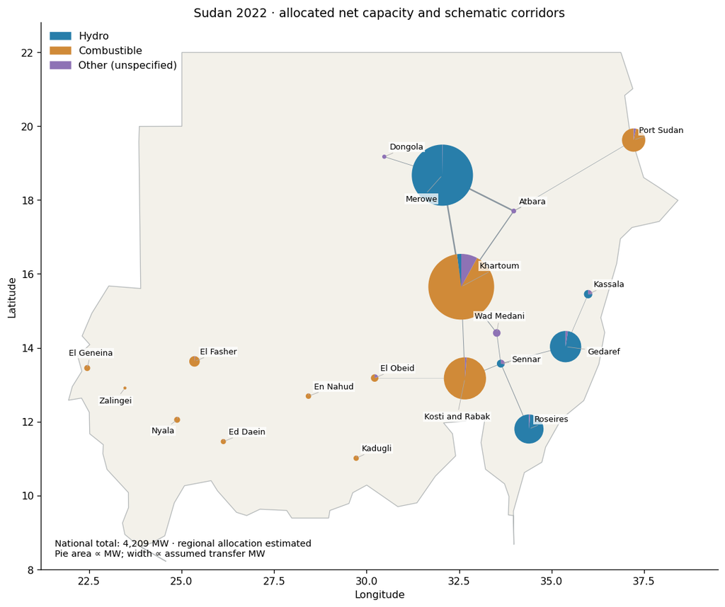

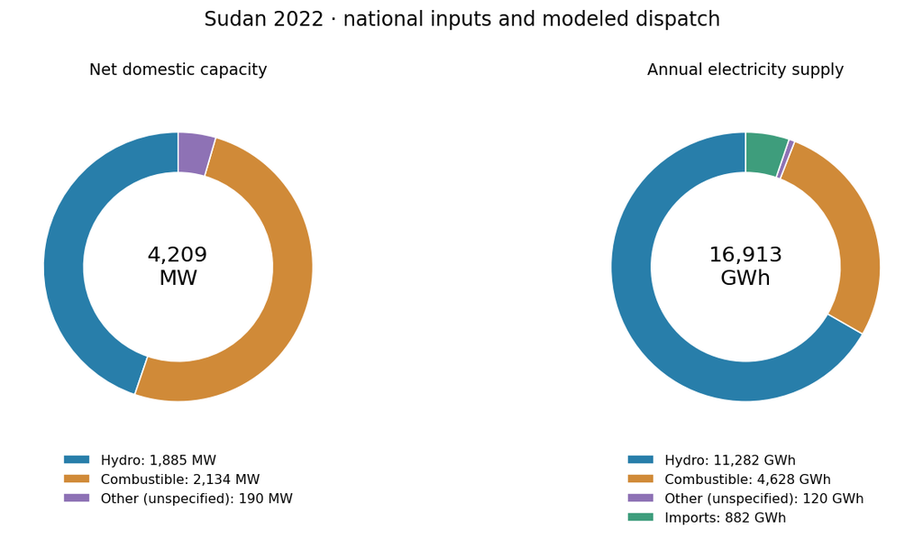

Regional generation pies show **where electricity is produced**, not the fuel mix consumed locally. Power can move between main-grid regions. Equal-sized donuts make small systems readable; the center gives each region's annual production. Imports and shortage are excluded here.

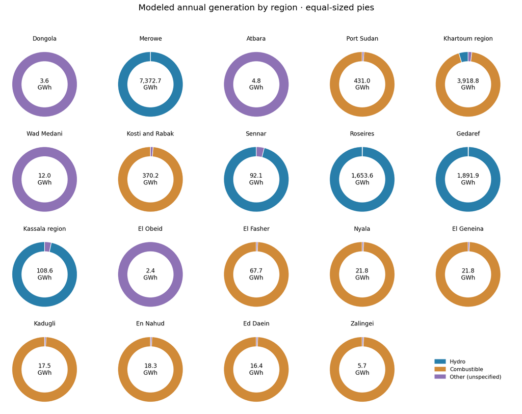

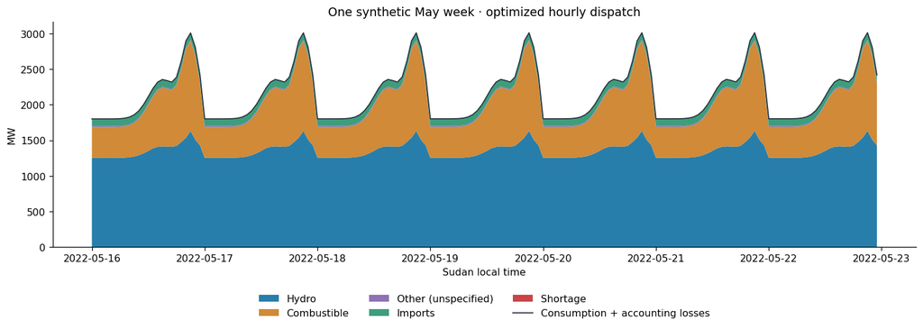

| bus | capacity_MW | consumer_input_GWh | loss_input_GWh | domestic_generation_GWh | shortage_GWh | served_supply_requirement_pct |
| --- | --- | --- | --- | --- | --- | --- |
| Dongola | 5.70 | 397.83 | 109.56 | 3.61 | 0.00 | 100.00 |
| Merowe | 1,233.48 | 132.61 | 36.52 | 7,372.68 | 0.00 | 100.00 |
| Atbara | 7.60 | 530.44 | 146.08 | 4.82 | 0.00 | 100.00 |
| PortSudan | 178.80 | 397.83 | 109.56 | 431.02 | 0.00 | 100.00 |
| Khartoum | 1,423.75 | 7,956.60 | 2,191.20 | 3,918.84 | 0.00 | 100.00 |
| WadMedani | 19.00 | 1,326.10 | 365.20 | 12.04 | 0.00 | 100.00 |
| Kosti | 584.61 | 530.44 | 146.08 | 370.25 | 0.00 | 100.00 |
| Sennar | 20.48 | 397.83 | 109.56 | 92.07 | 0.00 | 100.00 |
| Roseires | 279.67 | 265.22 | 73.04 | 1,653.62 | 0.00 | 100.00 |
| Gedaref | 322.88 | 530.44 | 146.08 | 1,891.92 | 0.00 | 100.00 |
| Kassala | 23.24 | 397.83 | 109.56 | 108.58 | 0.00 | 100.00 |
| ElObeid | 18.46 | 265.22 | 73.04 | 2.41 | 0.00 | 100.00 |
| ElFasher | 36.53 | 53.04 | 14.61 | 67.65 | 0.00 | 100.00 |
| Nyala | 11.79 | 17.11 | 4.71 | 21.82 | 0.00 | 100.00 |
| ElGeneina | 11.79 | 17.11 | 4.71 | 21.82 | 0.00 | 100.00 |
| Kadugli | 9.43 | 13.69 | 3.77 | 17.46 | 0.00 | 100.00 |
| EnNahud | 9.90 | 14.37 | 3.96 | 18.33 | 0.00 | 100.00 |
| EdDaein | 8.84 | 12.83 | 3.53 | 16.37 | 0.00 | 100.00 |
| Zalingei | 3.06 | 4.45 | 1.23 | 5.67 | 0.00 | 100.00 |

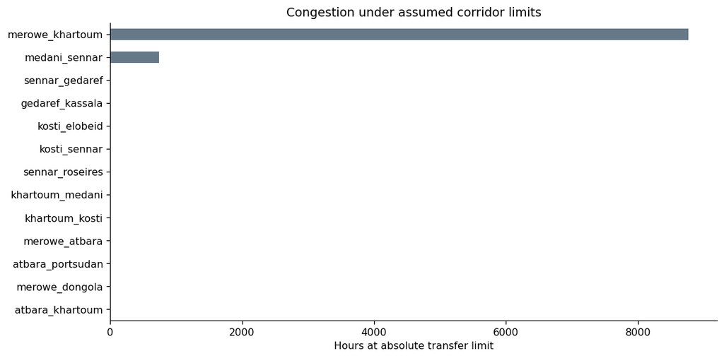

| name | assumed_limit_MW | mean_absolute_utilization_pct | hours_at_limit | net_bus0_to_bus1_GWh |
| --- | --- | --- | --- | --- |
| merowe_khartoum | 700.00 | 100.00 | 8760 | 6,132.00 |
| medani_sennar | 250.00 | 75.91 | 742 | -1,662.51 |
| merowe_dongola | 250.00 | 9.58 | 0 | 209.78 |
| atbara_khartoum | 450.00 | 2.88 | 0 | 113.71 |
| merowe_atbara | 700.00 | 14.05 | 0 | 861.78 |
| atbara_portsudan | 180.00 | 4.84 | 0 | 76.37 |
| khartoum_kosti | 300.00 | 0.00 | 0 | 0.00 |
| khartoum_medani | 300.00 | 0.64 | 0 | 16.75 |
| kosti_sennar | 250.00 | 29.32 | 0 | -642.12 |
| sennar_roseires | 300.00 | 50.05 | 0 | -1,315.36 |
| sennar_gedaref | 250.00 | 64.14 | 0 | -1,404.59 |
| gedaref_kassala | 180.00 | 25.29 | 0 | 398.81 |
| kosti_elobeid | 100.00 | 38.34 | 0 | 335.85 |

## 6. Test the assumptions

Two one-at-a-time sensitivities use the **same 8,760 hours**: 20% less hydro energy, and 50% lower corridor limits. These are stress tests, not forecasts or reconstructions of particular events. Annual imports, demand and installed capacity remain fixed. Greater thermal output or shortage reveals dependence on assumed hydro availability and network strength. These two tests do not cover uncertainty in regional demand shares, fleet allocation, fuel supply or import timing.

|  | hydro_GWh | combustible_GWh | imports_GWh | shortage_GWh | illustrative_operating_cost_million_USD |
| --- | --- | --- | --- | --- | --- |
| Baseline | 11,282.49 | 4,628.08 | 882.00 | 0.00 | 788.34 |
| Hydro energy -20% | 9,025.99 | 6,884.57 | 882.00 | 0.00 | 1,092.96 |
| Corridor limits -50% | 10,057.43 | 5,819.41 | 882.00 | 33.72 | 949.27 |

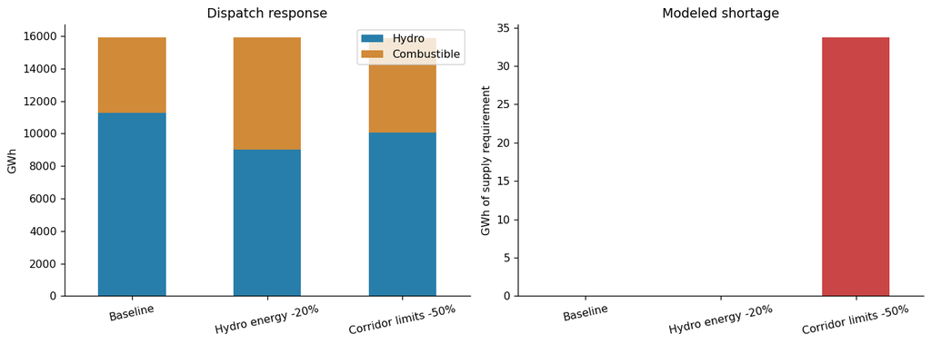

## 7. Save results and connect this reference to the study plan

The next cell writes the solved network, hourly dispatch, source/assumption tables and summaries to `results/`. PNG/SVG figures and the HTML are alternative views of this same analysis.

### What the existing results establish

The saved model is a nationally calibrated regional **transport-dispatch prototype**. Numerical checks pass, and the two stress tests show dependence on assumed hydro availability and corridor capacity. These results do not independently validate the network, establish historical costs or select new investments.

### The research question from here

**Where should post-war Sudan repair or extend the grid, where should it build mini-grids, and where can standalone systems meet the chosen service standard economically?**

| Next work | Why it is needed |
| --- | --- |
| Reconcile the 2022 asset register and regional geography | Replace allocation weights where evidence supports actual capacities and avoid counting upgrades twice |
| Add calibrated hydro seasonality and independent operating comparisons | Reduce unrealistic flexibility and separate calibration from validation |
| Build a georeferenced pilot demand/route/cost table | Locate households, businesses and critical loads and establish feasible connections |
| Compare grid, mini-grid and standalone alternatives at equal service | Add investment, repair, distribution, connection, storage and replacement costs |
| Couple local choices to regional supply and shared routes | Avoid a local cheap option creating infeasible or uncounted upstream costs |
| Scale only after pilot checks and uncertainty tests | Make national maps defensible and distinguish robust from assumption-sensitive choices |

These are **planned extensions**, not components hidden in the dispatch model. A constrained corridor in this notebook is not a recommendation to build a line. The historical locality table is not a ready-made village map.

The [overall plan](https://github.com/Elgenied/pypsa-sudan/blob/main/docs/STUDY_PLAN.md) describes the GIS, option-selection and PyPSA layers, milestones and intended paper outputs. The [evidence register](https://github.com/Elgenied/pypsa-sudan/blob/main/docs/EVIDENCE_AND_GAPS.md) prioritizes the missing inputs. The immediate deliverable is a small, cost-complete comparison that explains why each option wins.

**Run complete.** The solved network, input audit, hourly dispatch, regional results, sensitivity table and exportable figures are in `results/`.